# Methods of Empirical Finance

## Seminar (UE)

### Christoph Huber

### University of Innsbruck

#### Master in Banking and Finance

### Winter term 2019/20 (this version: 2019-11-19)

# Hypothesis Testing

### Methods of Empirical Finance

<footer></footer>

# Hypothesis Testing

Things to consider:

- Null Hypothesis ( `\(H_0\)` ) vs. Alternative Hypothesis ( `\(H_1, H_A\)` )

- Exploratory vs. Directional Hypotheses
  - Exploratory: e.g. `\(H_1\)`: `\(\mu_x \neq \mu_y\)`
  - Directional: e.g. `\(H_1\)`: `\(\mu_x > \mu_y\)`

- Type I and Type II errors

- Statistical significance and power

<footer></footer>

# Hypothesis Testing

### Review

Exploratory Hypothesis: `\(H_1\)`: `\(\mu_x \neq \mu_y\)`

`\(\alpha = 0.05\)`

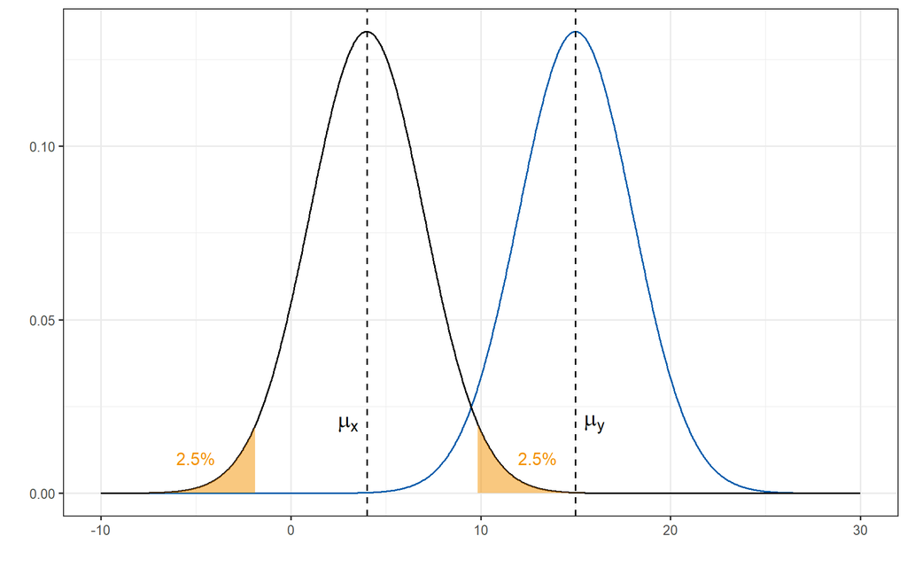

<footer></footer>

# Hypothesis Testing

### Review

Directional Hypothesis: `\(H_1\)`: `\(\mu_x < \mu_y\)`

`\(\alpha = 0.05\)`

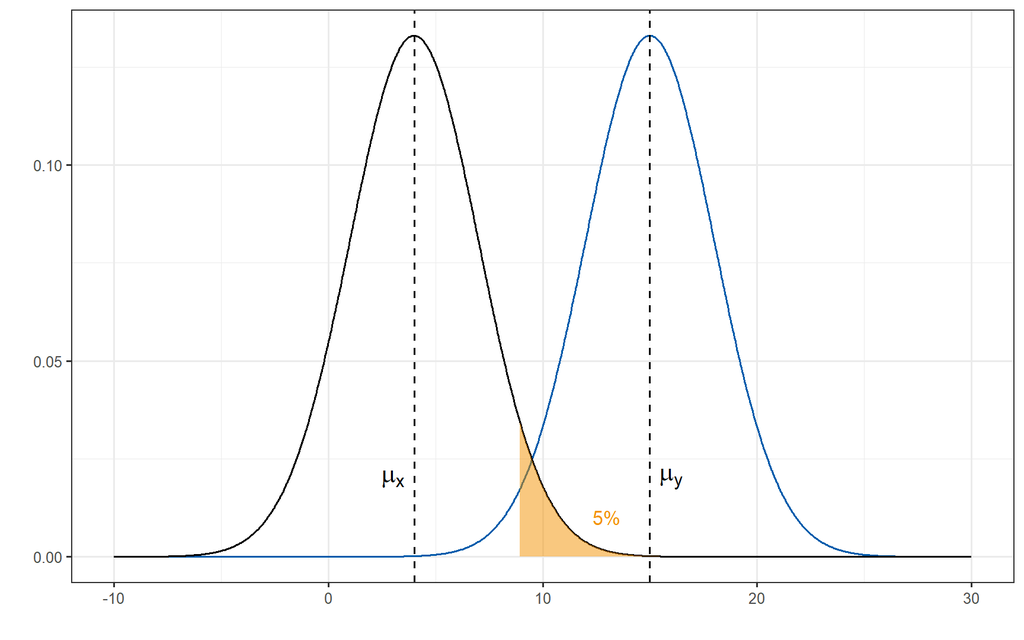

<footer></footer>

# Hypothesis Testing

### Review

`\(\alpha\)`, `\(\beta\)`, and `\(\pi\)`

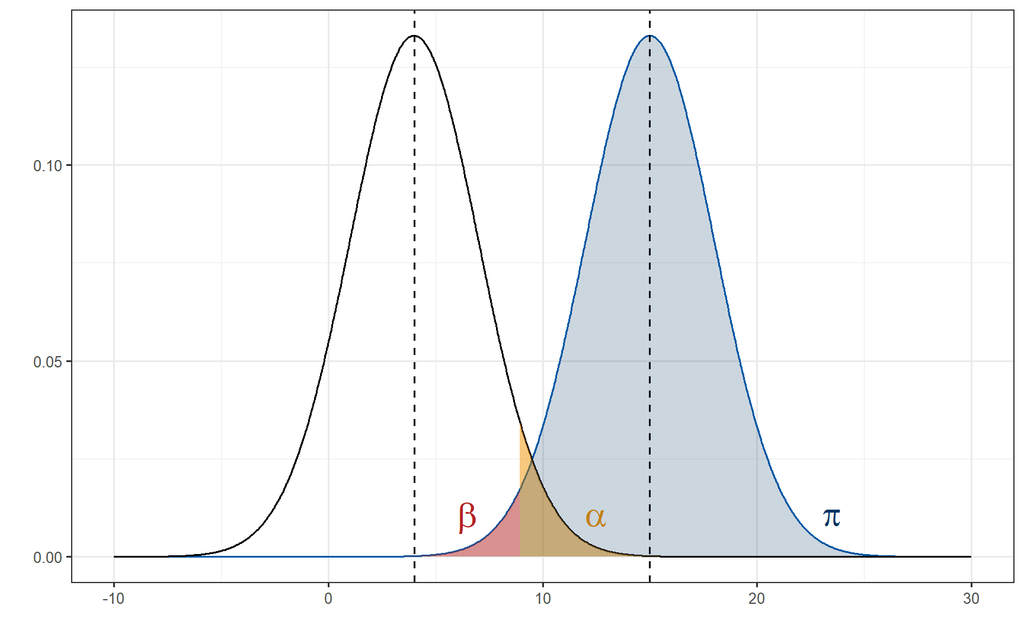

<footer></footer>

# Hypothesis Testing

### Review

Type I and Type II errors

|                           	|              	| Null hypothesis `\(H_0\)` is ... 	|                                        	|
|---------------------------	|--------------	|---------------------------------------	|----------------------------------------	|
|                           	|              	| _True_                                   	| _False_                                  	|
| __Decision about `\(H_0\)` ...__  	| _Don't reject_ 	|                  Correct inference                   	| Type II error  (false negative)  `\(\beta\)` 	|
|                           	| _Reject_       	| Type I error  (false positive)  `\(\alpha\)` 	|            Correct inference           	|

<footer></footer>

# Power Analysis

A test’s statistical power depends on the following factors:

- the significance criterion ( `\(\alpha \uparrow \rightarrow \pi \uparrow\)` )

- the sample size used to detect the effect ( `\(n \uparrow \rightarrow \pi \uparrow\)` )

- the magnitude of the effect, i.e. the effect size ( `\(d \uparrow \rightarrow \pi \uparrow\)` )

<footer></footer>

# Power Analysis

Several scenarios:

- Calculate the required _sample size_ for a given power:
  - given: power, effect size (Cohen's `\(d\)` ), significance level ( `\(\alpha\)` ), type of test

- Calculate the effect size you are able to detect for a given power and sample size:
  - given: power, number of observations (sample size `\(n\)` ), significance level ( `\(\alpha\)` ), type of test

Be careful: true power `\(\neq\)` observed power
`\(\rightarrow\)` do not use post-hoc power analyses!

<footer></footer>

# Power Analysis

### Software packages

R:

```r
require("pwr")
library(pwr)
```

`power.*` or `pwr.*` commands

Stata:

`power` command (see `help power`)

<footer></footer>

# Power Analysis

### Example 1

Kirchler, M., Palan, S. (2018) Immaterial and monetary gifts in economic transactions: evidence from the field. Experimental Economics 21. [Link](https://doi.org/10.1007/s10683-017-9536-1)

From Table 1, we see:

`\(\bar{x}_{NORMAL} = 106.03, s_{NORMAL} = 18.78, n_{NORMAL} = 36\)`
`\(\bar{x}_{COMPLIMENT} = 117.20, s_{COMPLIMENT} =  20.55, n_{COMPLIMENT} = 36\)`

Do <u>not</u> use this data for post-hoc power analysis (see [here](http://daniellakens.blogspot.com/2014/12/observed-power-and-what-to-do-if-your.html)),
but, e.g. for _calculating the required sample size_ or _calculating the targeted power_ for a new analysis.

<footer></footer>

# Power Analysis

### Example 1

Calculate `\(d\)`:
`\(d = \frac{\bar{x}_{NORMAL} - \bar{x}_{COMPLIMENT}}{\sqrt{s_{NORMAL}^2 + s_{COMPLIMENT}^2/2}}\)`

```r
d = (106.03 - 117.20)/(((18.78^2 + 20.55^2)/2)^(1/2))
print(d)
```

```
## [1] -0.5674399
```

Calculate power for `\(n = 80\)`:

```r
pwr.t.test(n = 80, d = -0.5674399, sig.level = 0.05)
```

```
##
##      Two-sample t test power calculation
##
##               n = 80
##               d = 0.5674399
##       sig.level = 0.05
##           power = 0.9459666
##     alternative = two.sided
##
## NOTE: n is number in *each* group
```

<footer></footer>

# Power Analysis

### Example 2

What sample size do you need to detect a medium effect size of `\(d = 0.5\)` with 90% power if you use `\(\alpha = 0.05\)`?

(using a two-sided `\(t\)`-test)

```r
pwr.t.test(d = 0.5, sig.level = 0.05, power = 0.9, type = c("two.sample"))
```

```
##
##      Two-sample t test power calculation
##
##               n = 85.03128
##               d = 0.5
##       sig.level = 0.05
##           power = 0.9
##     alternative = two.sided
##
## NOTE: n is number in *each* group
```

<footer></footer>

# Power Analysis

### What's an appropriate power?

- most fields use `\(\pi = 0.80\)` as a the conventional/standard power

- this implies a probability of a Type II error (false negative) of
  `\(\beta = 1 - \pi = 0.2\)` and therefore, with a conventional `\(\alpha = 0.05\)` a
  4-to-1 trade-off between `\(\beta\)`- and `\(\alpha\)`-risk

- however, depending on the field and research question, this might be
  inappropriate `\(\rightarrow\)` depending on field and research question,
  think about: _what is more important - avoiding false positives or false_
  _negatives?_

<footer></footer>

# _p_-values

Suppose you have an hypothesis that U.S. public companies with small boards of directors outperform companies with large boards. You create two value-weighted portfolios and test for differences in mean returns. The key parameter of interest, the mean performance difference, is significant with `\(p = 0.01\)`.

Consider the following six statements (true/false):

- (i) You have disproved the null hypothesis (no difference in mean performance).

- (ii) You have found the probability of the null hypothesis being true.

- (iii) You have proved the hypothesis that firms with small boards outperform firms with large boards.

- (iv) You can deduce the probability of your hypothesis (small better than large) being true.

- (v) If you reject the null hypothesis (no difference), you know the probability that you are making a mistake.

- (vi) You have a reliable finding in the sense that if, hypothetically, the experiment were repeated a large number of times, you would obtain a significant result 99% of the time.

__All of them are false!__

<footer></footer>

# _p_-values

### Definition

> A `\(p\)`-value is the probability of the observed data (or of more extreme
> data points), _given that the null hypothesis `\(H_0\)` is true_.

> The `\(p\)`-value indicates the probability of observing an effect, `\(D\)`, (or greater)
> given the null hypothesis `\(H_0\)` is true, that is,

`$$p(D|H_0)$$`

`$$\underline{\text{not}}\; p(H_0|D)\; !$$`

<footer></footer>

# Multiple Hypothesis Testing

### A comical illustration

[figure not shown]

From [https://xkcd.com/882/](https://xkcd.com/882/)

<footer></footer>

# Multiple Hypothesis Testing

### A comical illustration

[figure not shown]

From [https://xkcd.com/882/](https://xkcd.com/882/)

<footer></footer>

# Multiple Hypothesis Testing

### A comical illustration

[figure not shown]

From [https://xkcd.com/882/](https://xkcd.com/882/)

<footer></footer>

# Multiple Hypothesis Testing

`\(\rightarrow\)` testing multiple hypotheses simultaneously can be a problem

`\(Pr(\text{making a type I error}) = \alpha\)`

`\(Pr(\text{not making a type I error}) = 1 - \alpha\)`

`\(Pr(\text{not making a type I error }\textbf{in m tests}) = (1 - \alpha)^\textbf{m}\)`

Thus, with `\(\alpha = 0.05\)` and 20 hypotheses, we get a _family-wise error rate (FWER)_

`\(FWER = 1 - (1 - 0.05)^{20} = 0.642\)`,

i.e. the probability of at least 1 type I error is 64.2%!

<footer></footer>

# Multiple Hypothesis Testing

### Definitions

Family-wise error rate (FWER)

> _probability_ of false discoveries
> ...

False-discovery rate (FDR)

> _proportion_ of false discoveries
> ...

<footer></footer>

# Multiple Hypothesis Testing

### Possible solutions: `\(p\)`-value corrections

- Bonferroni correction

- controls FWER

- set significance cut-off at `\(\alpha / m\)` ( `\(m\)` ... number of tests)

- applied to example above: `\(\alpha / m = \frac{0.05}{20} = 0.0025\)`, `\(\textit{FWER} = 1 - (1 - 0.0025)^{20} = 0.049\)`

- very conservative

```r
pvalues <- runif(20)/10    # 20 random p-values
sort(pvalues)
```

```
##  [1] 0.0008945796 0.0073144469 0.0100053522 0.0260427771 0.0277374958
##  [6] 0.0286000621 0.0293739612 0.0415607119 0.0455102418 0.0583987980
## [11] 0.0585800305 0.0724405893 0.0754675027 0.0761702403 0.0813574215
## [16] 0.0906092151 0.0949040221 0.0954068775 0.0962204624 0.0971055656
```

```r
p.adjust(sort(pvalues), method = "bonferroni")
```

```
##  [1] 0.01789159 0.14628894 0.20010704 0.52085554 0.55474992 0.57200124
##  [7] 0.58747922 0.83121424 0.91020484 1.00000000 1.00000000 1.00000000
## [13] 1.00000000 1.00000000 1.00000000 1.00000000 1.00000000 1.00000000
## [19] 1.00000000 1.00000000
```

<footer></footer>

# Multiple Hypothesis Testing

### Possible solutions: `\(p\)`-value corrections

- Bonferroni correction

- Holm–Bonferroni correction

- controls FWER

- order the `\(p\)`-values from lowest to highest: `\(p_1 \leq p_2 \leq ... \leq p_k\)`

- set significance cut-off at `\(\frac{\alpha}{m + 1 - k}\)` (with `\(k\)` being the rank of the respective `\(p\)`-value)

- applied to example above:

`\(\frac{\alpha}{m + 1 - k} = \frac{0.05}{20 + 1 - 1} = 0.0025\)` for the smallest `\(p\)` ( `\(k=1\)` ),

`\(\frac{\alpha}{m + 1 - k} = \frac{0.05}{20 + 1 - 2} = 0.00263\)` for the second-smallest `\(p\)` ( `\(k=2\)` ),
    and so on until

`\(\frac{\alpha}{m + 1 - k} = \frac{0.05}{20 + 1 - 20} = 0.05\)` for the largest `\(p\)` ( `\(k=20\)` )

```r
p.adjust(sort(pvalues), method = "holm")
```

```
##  [1] 0.01789159 0.13897449 0.18009634 0.44272721 0.44379993 0.44379993
##  [7] 0.44379993 0.54028925 0.54612290 0.64238678 0.64238678 0.65196530
## [13] 0.65196530 0.65196530 0.65196530 0.65196530 0.65196530 0.65196530
## [19] 0.65196530 0.65196530
```

<footer></footer>

# Multiple Hypothesis Testing

### Possible solutions: `\(p\)`-value corrections

- Bonferroni correction

- Holm–Bonferroni correction

- Benjamini, Hochberg, and Yekutieli correction

- controls FDR

- order the `\(p\)`-values from lowest to highest: `\(p_1 \leq p_2 \leq ... \leq p_k\)`

- starting from `\(k\)`, identify the first `\(i\)` such that `\(p_i < \frac{i}{k} \alpha\)`

- declare all tests `\(1, ..., i\)` significant, tests `\(i + 1, ..., k\)` not significant

```r
p.adjust(sort(pvalues), method = "BH")
```

```
##  [1] 0.01789159 0.06670235 0.06670235 0.08392560 0.08392560 0.08392560
##  [7] 0.08392560 0.09710557 0.09710557 0.09710557 0.09710557 0.09710557
## [13] 0.09710557 0.09710557 0.09710557 0.09710557 0.09710557 0.09710557
## [19] 0.09710557 0.09710557
```

- Several other correction procedures

<footer></footer>

# Related Literature

- Hoenig, J. M., & Heisey, D. M. (2001). The Abuse of Power. The American Statistician, 55(1), 19–24.

- Benjamin, D. J., Berger, J. O., Johannesson, M., Nosek, B. A., Wagenmakers, E.-J., Berk, R., … Johnson, V. E. (2018). Redefine statistical significance. Nature Human Behaviour, 2(1), 6–10.

- Harvey, C. R., Liu, Y., & Zhu, H. (2016). ... and the Cross-Section of Expected Returns. Review of Financial Studies, 29(1), 5–68.

- Harvey, C. R. (2017). The Scientific Outlook in Financial Economics. The Journal of Finance, 72(4), 1399–1440.

# Your turn

- Load the data in `sp500_data.csv` again

- Think about interesting questions and formulate hypotheses you could test
  with these data

- Test your hypothesis(-es) using appropriate tests

- Can you reject the `\(H_0\)`?

- Comment on upcoming issues regarding the statistical power, multiple
  hyptheses, etc.